# Practical Machine Learning Course Project

Simon Gurcke

21 Mar 2015

## Synopsis

The goal of this project is to predict the manner in which a number of subjects performed certain exercises. The data stems from:

*Velloso, E.; Bulling, A.; Gellersen, H.; Ugulino, W.; Fuks, H. Qualitative Activity Recognition of Weight Lifting Exercises. Proceedings of 4th International Conference in Cooperation with SIGCHI (Augmented Human ’13) . Stuttgart, Germany: ACM SIGCHI, 2013.*

Read more here: http://groupware.les.inf.puc-rio.br/har

There are 5 classes (A, B, C, D and E) of how an exercise was performed. Class A represents a good performance, while all the other classes represent different ways of doing the exercise wrong. The prediction of the class is to be based on the data gathered from a number of sensors on the participants body and training devices.

## Required packages

```r
library(parallel, quietly = TRUE)
library(doParallel, quietly = TRUE)
library(randomForest, quietly = TRUE)
library(caret, quietly = TRUE)
```

## Load and prepare the data

```r
testing <- read.csv('pml-testing.csv')
training <- read.csv('pml-training.csv')

# Create a smaller subset of the training data
partition1 <- createDataPartition(training$classe, p = .1, list = FALSE)
trainingSubset <- training[partition1,]

# From the rest create a validation subset
validationSubset <- training[-partition1,]
partition2 <- createDataPartition(validationSubset$classe, p = .01, list = FALSE)
validationSubset <- validationSubset[partition2,]

# Leave only the raw data columns in training subset
cols <- colnames(training)
colsRaw <- cols[!grepl("^(max|min|skewness|kurtosis|amplitude|stddev|var|avg)_", cols)]
colsRaw <- colsRaw[!(colsRaw %in% c("X", "user_name", "raw_timestamp_part_1", "raw_timestamp_part_2", "cvtd_timestamp", "new_window", "num_window"))]
trainingSubset <- trainingSubset[,colsRaw]
```

## Near zero variance analysis

In an attempt to further reduce the number of predictors we perform a near zero variance analysis.

```r
nearZeroVar(trainingSubset, saveMetrics = TRUE)
```

```
##                      freqRatio percentUnique zeroVar   nzv
## roll_belt                1.000       20.6721   FALSE FALSE
## pitch_belt               1.000       42.7189   FALSE FALSE
## yaw_belt                 1.036       33.7067   FALSE FALSE
## total_accel_belt         1.005        1.2729   FALSE FALSE
## gyros_belt_x             1.068        4.1242   FALSE FALSE
## gyros_belt_y             1.101        2.0876   FALSE FALSE
## gyros_belt_z             1.230        5.9063   FALSE FALSE
## accel_belt_x             1.123        5.9572   FALSE FALSE
## accel_belt_y             1.236        5.2953   FALSE FALSE
## accel_belt_z             1.097        9.9796   FALSE FALSE
## magnet_belt_x            1.026        9.7251   FALSE FALSE
## magnet_belt_y            1.200        9.3177   FALSE FALSE
## magnet_belt_z            1.067       13.7475   FALSE FALSE
## roll_arm                33.800       49.5927   FALSE FALSE
## pitch_arm               42.250       54.5825   FALSE FALSE
## yaw_arm                 33.800       54.9389   FALSE FALSE
## total_accel_arm          1.011        3.1568   FALSE FALSE
## gyros_arm_x              1.036       26.1202   FALSE FALSE
## gyros_arm_y              1.913       14.3585   FALSE FALSE
## gyros_arm_z              1.327        9.0122   FALSE FALSE
## accel_arm_x              1.111       28.5132   FALSE FALSE
## accel_arm_y              1.524       22.1996   FALSE FALSE
## accel_arm_z              1.071       27.8513   FALSE FALSE
## magnet_arm_x             1.167       45.8758   FALSE FALSE
## magnet_arm_y             1.250       35.1324   FALSE FALSE
## magnet_arm_z             1.154       40.3768   FALSE FALSE
## roll_dumbbell            1.267       92.3116   FALSE FALSE
## pitch_dumbbell           1.632       91.2933   FALSE FALSE
## yaw_dumbbell             1.267       93.1772   FALSE FALSE
## total_accel_dumbbell     1.007        2.0367   FALSE FALSE
## gyros_dumbbell_x         1.082        8.4521   FALSE FALSE
## gyros_dumbbell_y         1.312        9.9796   FALSE FALSE
## gyros_dumbbell_z         1.030        7.0265   FALSE FALSE
## accel_dumbbell_x         1.028       13.6965   FALSE FALSE
## accel_dumbbell_y         1.346       17.7699   FALSE FALSE
## accel_dumbbell_z         1.037       16.5988   FALSE FALSE
## magnet_dumbbell_x        1.000       29.1752   FALSE FALSE
## magnet_dumbbell_y        1.217       29.2261   FALSE FALSE
## magnet_dumbbell_z        1.000       24.5927   FALSE FALSE
## roll_forearm             9.829       31.1100   FALSE FALSE
## pitch_forearm           44.778       47.8106   FALSE FALSE
## yaw_forearm             18.318       35.5906   FALSE FALSE
## total_accel_forearm      1.165        3.0041   FALSE FALSE
## gyros_forearm_x          1.041       10.7434   FALSE FALSE
## gyros_forearm_y          1.190       27.9532   FALSE FALSE
## gyros_forearm_z          1.062       10.3360   FALSE FALSE
## accel_forearm_x          1.000       32.4847   FALSE FALSE
## accel_forearm_y          1.364       36.0998   FALSE FALSE
## accel_forearm_z          1.100       21.7413   FALSE FALSE
## magnet_forearm_x         1.000       43.9409   FALSE FALSE
## magnet_forearm_y         1.071       47.7597   FALSE FALSE
## magnet_forearm_z         1.111       45.1629   FALSE FALSE
## classe                   1.468        0.2546   FALSE FALSE
```

## Build the model

For classification we use random forests with cross-validation, because we expect the best results from this algorithm. To enhance the performance of the training process we use parallelization.

```r
# Start parallelization on 3 cores
registerDoParallel(prl <- makeForkCluster(3))

# Train a model with 4-fold cross-validation and 10 repeats
ctrl <- trainControl(method = "repeatedcv", number = 4, repeats = 10)
fit <- train(classe ~ ., data = trainingSubset, method = "rf",
             trControl = ctrl, ntree = 80)

# Stop parallelization
stopCluster(prl)

fit
```

```
## Random Forest
##
## 1964 samples
##   52 predictor
##    5 classes: 'A', 'B', 'C', 'D', 'E'
##
## No pre-processing
## Resampling: Cross-Validated (4 fold, repeated 10 times)
##
## Summary of sample sizes: 1472, 1473, 1473, 1474, 1473, 1473, ...
##
## Resampling results across tuning parameters:
##
##   mtry  Accuracy  Kappa   Accuracy SD  Kappa SD
##    2    0.9194    0.8981  0.01269      0.01609
##   27    0.9257    0.9059  0.01233      0.01563
##   52    0.9226    0.9020  0.01126      0.01429
##
## Accuracy was used to select the optimal model using  the largest value.
## The final value used for the model was mtry = 27.
```

We can see the importance of each predictor in the final model in the following plot.

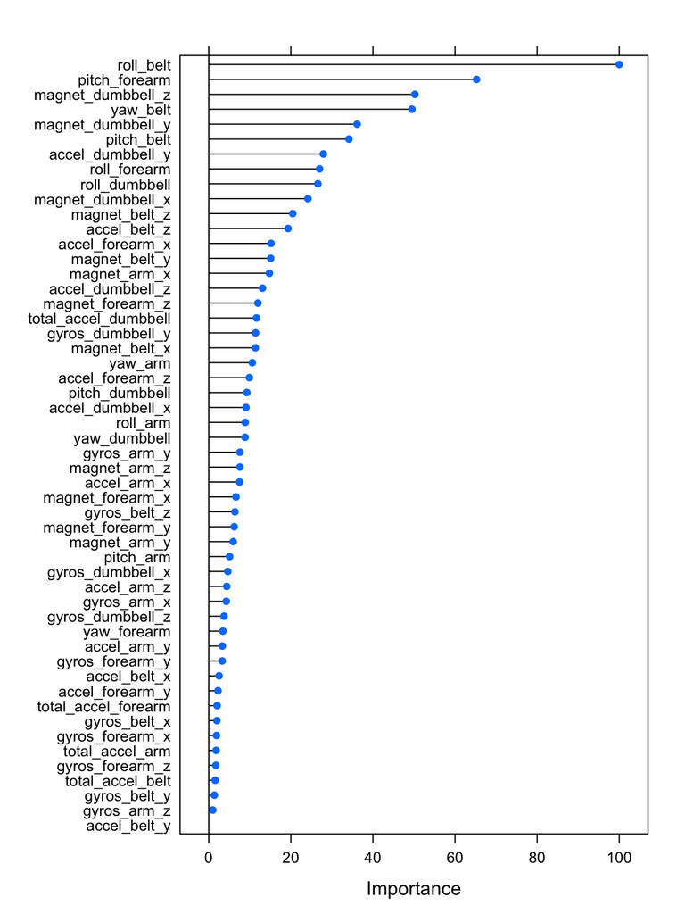

```r
plot(varImp(fit))
```

## Error rate

After fitting the model we estimate the out of sample error rate based on the validation set.

```r
# Predict on validation subset
pred <- predict(fit, validationSubset)

# Calculate accuracy and error rate
accuracy <- sum(pred == validationSubset$classe) / length(pred)
error <- 1 - accuracy
```

So the estimated out of sample error rate is 0.06.